# logistic_regression_model

2026-05-25

# Predicting Student Pass/Fail with LASSO Logistic Regression.

Datasets : UCI Student Performance (Math + Portuguese)

Target : **pass** = 1 if G3 >= 10, else 0

**Domain problem** - Schools want to flag students at risk of failing the final exam early enough to intervene, so they can work on their performance before the final exam.

**Data Science problem** - Binary classification of pass/fail from demographic family, behavioral features and previous grades.

#### Packages used

```r
library(glmnet) # LASSO logistic regression with CV
library(pROC) # ROC curve and AUC
library(corrplot) # To plot correlation heatmap
```

#### Set working directory and load both datasets

```r
setwd("C:/Users/Ashutosh/Stat5009_group17")
d1 <- read.csv("student-mat.csv", header = T, sep = ";")   # Math
d2 <- read.csv("student-por.csv", header = T, sep = ";")   # Portuguese
```

## PART 1 : MATH (d1)

#### 1. Inspect the datasets

```r
head(d1)
```

```
##   school sex age address famsize Pstatus Medu Fedu     Mjob     Fjob     reason
## 1     GP   F  18       U     GT3       A    4    4  at_home  teacher     course
## 2     GP   F  17       U     GT3       T    1    1  at_home    other     course
## 3     GP   F  15       U     LE3       T    1    1  at_home    other      other
## 4     GP   F  15       U     GT3       T    4    2   health services       home
## 5     GP   F  16       U     GT3       T    3    3    other    other       home
## 6     GP   M  16       U     LE3       T    4    3 services    other reputation
##   guardian traveltime studytime failures schoolsup famsup paid activities
## 1   mother          2         2        0       yes     no   no         no
## 2   father          1         2        0        no    yes   no         no
## 3   mother          1         2        3       yes     no  yes         no
## 4   mother          1         3        0        no    yes  yes        yes
## 5   father          1         2        0        no    yes  yes         no
## 6   mother          1         2        0        no    yes  yes        yes
##   nursery higher internet romantic famrel freetime goout Dalc Walc health
## 1     yes    yes       no       no      4        3     4    1    1      3
## 2      no    yes      yes       no      5        3     3    1    1      3
## 3     yes    yes      yes       no      4        3     2    2    3      3
## 4     yes    yes      yes      yes      3        2     2    1    1      5
## 5     yes    yes       no       no      4        3     2    1    2      5
## 6     yes    yes      yes       no      5        4     2    1    2      5
##   absences G1 G2 G3
## 1        6  5  6  6
## 2        4  5  5  6
## 3       10  7  8 10
## 4        2 15 14 15
## 5        4  6 10 10
## 6       10 15 15 15
```

```r
str(d1)
```

```
## 'data.frame':    395 obs. of  33 variables:
##  $ school    : chr  "GP" "GP" "GP" "GP" ...
##  $ sex       : chr  "F" "F" "F" "F" ...
##  $ age       : int  18 17 15 15 16 16 16 17 15 15 ...
##  $ address   : chr  "U" "U" "U" "U" ...
##  $ famsize   : chr  "GT3" "GT3" "LE3" "GT3" ...
##  $ Pstatus   : chr  "A" "T" "T" "T" ...
##  $ Medu      : int  4 1 1 4 3 4 2 4 3 3 ...
##  $ Fedu      : int  4 1 1 2 3 3 2 4 2 4 ...
##  $ Mjob      : chr  "at_home" "at_home" "at_home" "health" ...
##  $ Fjob      : chr  "teacher" "other" "other" "services" ...
##  $ reason    : chr  "course" "course" "other" "home" ...
##  $ guardian  : chr  "mother" "father" "mother" "mother" ...
##  $ traveltime: int  2 1 1 1 1 1 1 2 1 1 ...
##  $ studytime : int  2 2 2 3 2 2 2 2 2 2 ...
```

[output cut: 19 more lines]

```r
dim(d1)
```

```
## [1] 395  33
```

#### 2. Build binary response

**Pass = 1 if final grade G3 >= 10 (Portuguese 0-19 scale)**

```r
d1$pass <- ifelse(d1$G3 >= 10, 1, 0)
# Drop G3 - as it would leak the answer into the features
d1 <- d1[ , !names(d1) %in% "G3"]
```

To show Class balance:

```r
table(d1$pass) / nrow(d1)
```

```
##
##         0         1
## 0.3291139 0.6708861
```

### 3. Exploratory Data Analysis

#### 3a. Class balance bar chart

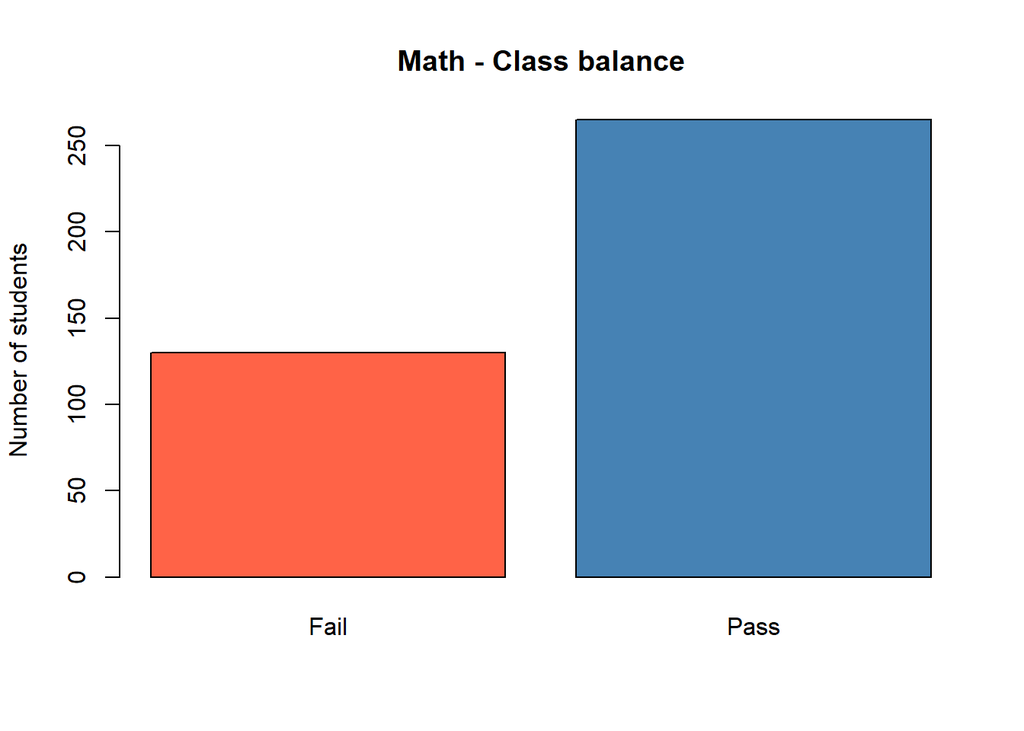

```r
par(mfrow = c(1, 1))
barplot(table(d1$pass),
        names.arg = c("Fail", "Pass"),
        col  = c("tomato", "steelblue"),
        main = "Math - Class balance",
        ylab = "Number of students")
```

#### 3b. Boxplots - continuous features vs pass(response)

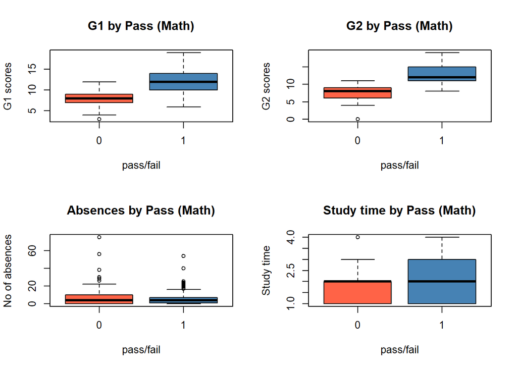

```r
par(mfrow = c(2, 2))

boxplot(G1 ~ pass, data = d1,
        main = "G1 by Pass (Math)",
        xlab = "pass/fail", ylab = "G1 scores",
        col = c("tomato", "steelblue"))

boxplot(G2 ~ pass, data = d1,
        main = "G2 by Pass (Math)",
        xlab = "pass/fail", ylab = "G2 scores",
        col = c("tomato", "steelblue"))

boxplot(absences ~ pass, data = d1,
        main = "Absences by Pass (Math)",
        xlab = "pass/fail", ylab = "No of absences",
        col = c("tomato", "steelblue"))

boxplot(studytime ~ pass, data = d1,
        main = "Study time by Pass (Math)",
        xlab = "pass/fail", ylab = "Study time",
        col = c("tomato", "steelblue"))
```

#### 3c. Categorical features vs pass rate

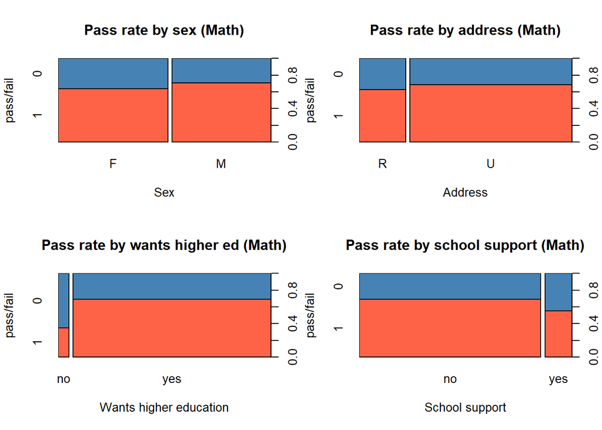

```r
par(mfrow = c(2, 2))
spineplot(as.factor(d1$pass) ~ as.factor(d1$sex),
          xlab = "Sex", ylab = "pass/fail",
          main = "Pass rate by sex (Math)",
          col = c("tomato", "steelblue"))
spineplot(as.factor(d1$pass) ~ as.factor(d1$address),
          xlab = "Address", ylab = "pass/fail",
          main = "Pass rate by address (Math)",
          col = c("tomato", "steelblue"))
spineplot(as.factor(d1$pass) ~ as.factor(d1$higher),
          xlab = "Wants higher education", ylab = "pass/fail",
          main = "Pass rate by wants higher ed (Math)",
          col = c("tomato", "steelblue"))
spineplot(as.factor(d1$pass) ~ as.factor(d1$schoolsup),
          xlab = "School support", ylab = "pass/fail",
          main = "Pass rate by school support (Math)",
          col = c("tomato", "steelblue"))
```

#### 3d. Past failures vs pass rate

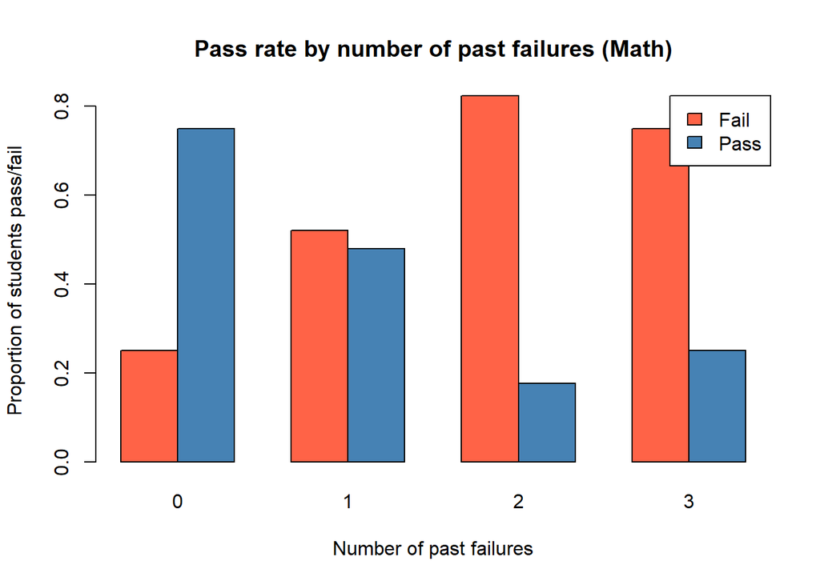

```r
# Past failures vs pass rate
par(mfrow = c(1, 1))

# Build a table: rows = no of failures (0,1,2,3), columns = fail/pass
tab <- table(d1$failures, d1$pass)
colnames(tab) <- c("Fail", "Pass")

# Convert to proportions WITHIN each failure level
# (each row sums to 1, so we see "of students with X failures, what % passed")
prop_tab <- prop.table(tab, margin = 1)

barplot(t(prop_tab),
        beside = TRUE,
        col = c("tomato", "steelblue"),
        legend.text = c("Fail", "Pass"),
        args.legend = list(x = "topright"),
        main = "Pass rate by number of past failures (Math)",
        xlab = "Number of past failures",
        ylab = "Proportion of students pass/fail")
```

##### It looks like students with less number of past failures have a **higher pass rate**

#### 3e. Correlation heatmap of numeric features

##### Shows multicollinearity (G1 and G2 will be highly correlated)

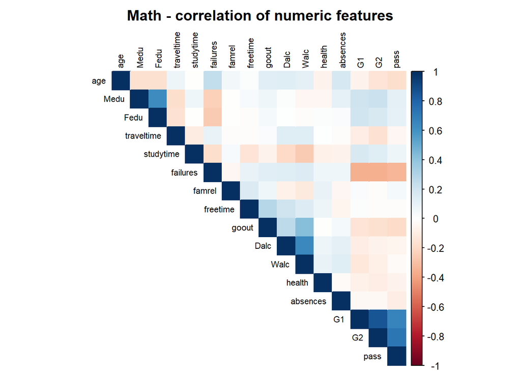

```r
num_cols <- sapply(d1, is.numeric)
cor_mat  <- cor(d1[, num_cols])
corrplot(cor_mat, method = "color", type = "upper",
         tl.cex = 0.7, tl.col = "black",
         title = "Math - correlation of numeric features",
         mar = c(0, 0, 2, 0))
```

#### 4. Train / Test split

```r
d1$pass <- as.factor(d1$pass)   # glmnet needs a factor for binomial

n <- nrow(d1)
set.seed(234)
s.in <- sample(1:n, size = 0.8 * n)

d1.tr <- d1[s.in, ]
d1.ts <- d1[-s.in, ]
```

```r
cor(d1.tr$G1, d1.tr$G2)
```

```
## [1] 0.871781
```

Build numeric feature matrix (glmnet needs a matrix, not a data frame) model.matrix one-hot encodes categorical variables. “-1” drops the intercept column (glmnet adds its own).

```r
x.tr <- model.matrix(pass ~ ., data = d1.tr)[ , -1]
x.ts <- model.matrix(pass ~ ., data = d1.ts)[ , -1]
y.tr <- d1.tr$pass
```

#### 5. Fit LASSO logistic regression

alpha = 1 -> LASSO (absolute-value penalty, zeroes out weak features)

CV picks the best shrinkage parameter (lambda) automatically.

We chose LASSO Logistic Regression as the model has too many features, which are likely correlated or irrelevant

The key assumptions of LASSO model are:

• A linear relationship exists between the features and the log-odds of the response.

• LASSO assumes that the underlying true model is sparse, meaning only a small subset of the total features have a significant impact on the target variable. Therefore, it penalizes the absolute values of less important, correlated features to zero. It is therefore known as a feature selection model.

• The feature sets are independant (no multicollinearity) is also a key assumption

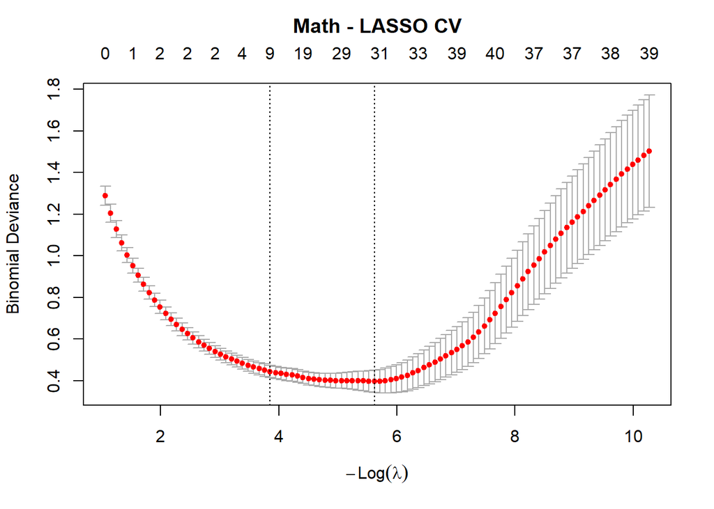

```r
set.seed(234)
cv.l <- cv.glmnet(x = x.tr, y = y.tr,
                  alpha = 1,
                  family = "binomial",
                  nfolds = 10,
                  type.measure = "deviance")
plot(cv.l)
title("Math - LASSO CV", line = 2.5)
```

##### G1 and G2 are highly correlated but dropping G2 increases CV -error

```r
x.tr.noG2 <- x.tr[, colnames(x.tr) != "G2"]
cv.test <- cv.glmnet(x.tr.noG2, y.tr, alpha = 1, family = "binomial")
min(cv.test$cvm) #test model cv, where we dropped G2
```

```
## [1] 0.6205526
```

```r
min(cv.l$cvm) # Original model CV
```

```
## [1] 0.3971792
```

```r
blam.1 <- cv.l$lambda.min        # best lambda
blam.1
```

```
## [1] 0.003622192
```

```r
# Fit final model at chosen lambda
mod.l1 <- glmnet(x = x.tr, y = y.tr,
                 alpha = 1,
                 lambda = blam.1,
                 family = "binomial")

# Which features survived?
coef(mod.l1)
```

```
## 42 x 1 sparse Matrix of class "dgCMatrix"
##                             s0
## (Intercept)      -10.504793986
## schoolMS           1.427465516
## sexM              -0.974411455
## age               -0.661706842
## addressU           .
## famsizeLE3        -0.729897093
## PstatusT          -0.622995121
## Medu              -0.091846610
## Fedu              -0.165768851
## Mjobhealth        -0.863213249
## Mjobother         -0.733115208
## Mjobservices       0.058598984
## Mjobteacher       -0.694573836
## Fjobhealth         .
## Fjobother          1.781143619
## Fjobservices       .
## Fjobteacher        1.147074504
## reasonhome         0.606817265
## reasonother        0.817265515
## reasonreputation   0.334516829
## guardianmother     0.440517168
## guardianother      .
## traveltime         0.310305305
## studytime         -0.877695372
## failures           .
## schoolsupyes      -0.137235977
## famsupyes         -0.009967797
## paidyes            .
## activitiesyes     -0.500713993
## nurseryyes         .
## higheryes         -0.462102308
## internetyes        0.611075821
## romanticyes       -1.072267818
## famrel             0.881170730
## freetime           .
## goout             -0.185918962
## Dalc               .
## Walc               0.328233895
## health            -0.212306808
## absences          -0.022236375
## G1                 0.462280999
## G2                 1.858387139
```

```r
sum(coef(mod.l1) != 0) - 1       # count of non-zero (excl. intercept)
```

```
## [1] 32
```

#### 6. Predict on the test set

```r
prob.1 <- predict(mod.l1, newx = x.ts, type = "response")
pred.1 <- ifelse(prob.1 > 0.5, 1, 0)
```

#### 7. Model Evaluation

```r
# Confusion matrix
cm.mat <- table(Predicted = pred.1, Actual = d1.ts$pass)
cm.mat
```

```
##          Actual
## Predicted  0  1
##         0 21  2
##         1  1 55
```

```r
# Accuracy, sensitivity, specificity
TN.m <- cm.mat["0","0"]; FP.m <- cm.mat["1","0"]
FN.m <- cm.mat["0","1"]; TP.m <- cm.mat["1","1"]

acc.mat  <- (TP.m + TN.m) / (TP.m + TN.m + FP.m + FN.m)
sens.mat <- TP.m / (TP.m + FN.m)
spec.mat <- TN.m / (TN.m + FP.m)

acc.mat
```

```
## [1] 0.9620253
```

```r
sens.mat
```

```
## [1] 0.9649123
```

```r
spec.mat
```

```
## [1] 0.9545455
```

##### ROC curve and AUC

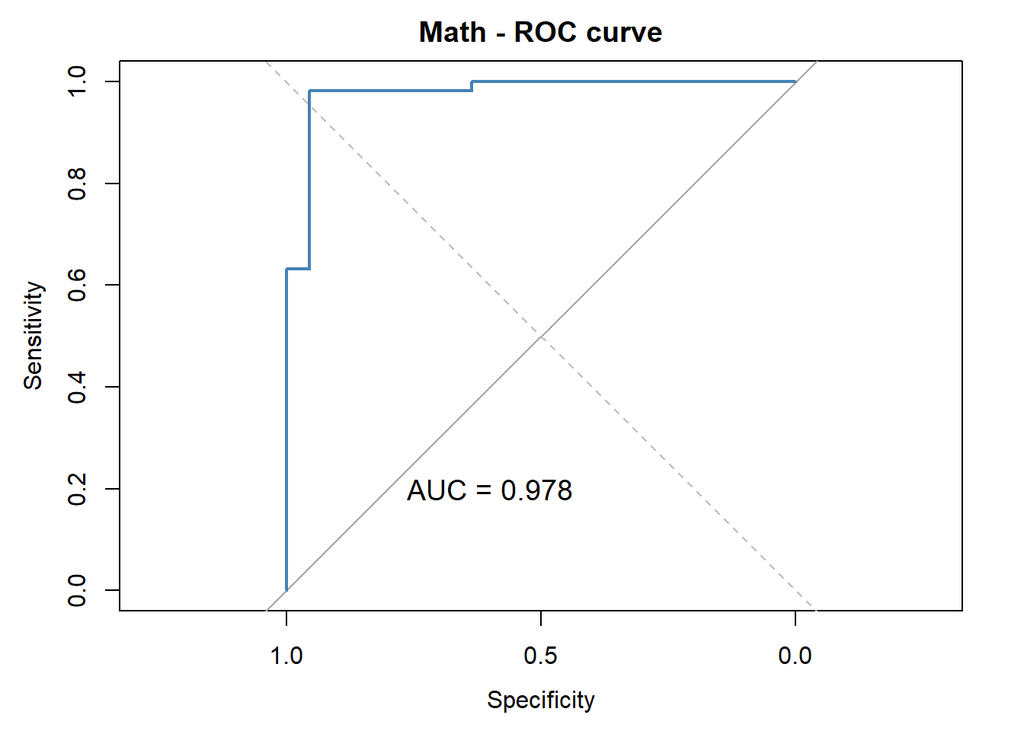

```r
# ROC curve and AUC
roc.1 <- roc(response  = as.numeric(as.character(d1.ts$pass)),
             predictor = as.numeric(prob.1),
             quiet = TRUE)

# To plot the AUC curve
plot(roc.1, col = "steelblue", lwd = 2,
     main = "Math - ROC curve")
abline(a = 0, b = 1, lty = 2, col = "grey")
text(0.6, 0.2, paste("AUC =", round(auc(roc.1), 3)), cex = 1.2)
```

```r
auc.mat <- as.numeric(auc(roc.1))
auc.mat
```

```
## [1] 0.9776715
```

## PART 2 : PORTUGUESE (d2)

#### 1. Inspect

```r
head(d2)
```

```
##   school sex age address famsize Pstatus Medu Fedu     Mjob     Fjob     reason
## 1     GP   F  18       U     GT3       A    4    4  at_home  teacher     course
## 2     GP   F  17       U     GT3       T    1    1  at_home    other     course
## 3     GP   F  15       U     LE3       T    1    1  at_home    other      other
## 4     GP   F  15       U     GT3       T    4    2   health services       home
## 5     GP   F  16       U     GT3       T    3    3    other    other       home
## 6     GP   M  16       U     LE3       T    4    3 services    other reputation
##   guardian traveltime studytime failures schoolsup famsup paid activities
## 1   mother          2         2        0       yes     no   no         no
## 2   father          1         2        0        no    yes   no         no
## 3   mother          1         2        0       yes     no   no         no
## 4   mother          1         3        0        no    yes   no        yes
## 5   father          1         2        0        no    yes   no         no
## 6   mother          1         2        0        no    yes   no        yes
##   nursery higher internet romantic famrel freetime goout Dalc Walc health
## 1     yes    yes       no       no      4        3     4    1    1      3
## 2      no    yes      yes       no      5        3     3    1    1      3
## 3     yes    yes      yes       no      4        3     2    2    3      3
## 4     yes    yes      yes      yes      3        2     2    1    1      5
## 5     yes    yes       no       no      4        3     2    1    2      5
## 6     yes    yes      yes       no      5        4     2    1    2      5
##   absences G1 G2 G3
## 1        4  0 11 11
## 2        2  9 11 11
## 3        6 12 13 12
## 4        0 14 14 14
## 5        0 11 13 13
## 6        6 12 12 13
```

```r
str(d2)
```

```
## 'data.frame':    649 obs. of  33 variables:
##  $ school    : chr  "GP" "GP" "GP" "GP" ...
##  $ sex       : chr  "F" "F" "F" "F" ...
##  $ age       : int  18 17 15 15 16 16 16 17 15 15 ...
##  $ address   : chr  "U" "U" "U" "U" ...
##  $ famsize   : chr  "GT3" "GT3" "LE3" "GT3" ...
##  $ Pstatus   : chr  "A" "T" "T" "T" ...
##  $ Medu      : int  4 1 1 4 3 4 2 4 3 3 ...
##  $ Fedu      : int  4 1 1 2 3 3 2 4 2 4 ...
##  $ Mjob      : chr  "at_home" "at_home" "at_home" "health" ...
##  $ Fjob      : chr  "teacher" "other" "other" "services" ...
##  $ reason    : chr  "course" "course" "other" "home" ...
##  $ guardian  : chr  "mother" "father" "mother" "mother" ...
##  $ traveltime: int  2 1 1 1 1 1 1 2 1 1 ...
##  $ studytime : int  2 2 2 3 2 2 2 2 2 2 ...
```

[output cut: 19 more lines]

```r
dim(d2)
```

```
## [1] 649  33
```

#### 2. Build binary response

```r
d2$pass <- ifelse(d2$G3 >= 10, 1, 0)
d2 <- d2[ , !names(d2) %in% "G3"]

table(d2$pass) / nrow(d2)
```

```
##
##         0         1
## 0.1540832 0.8459168
```

#### 3. Exploratory Data Analysis

##### 3a. Class balance

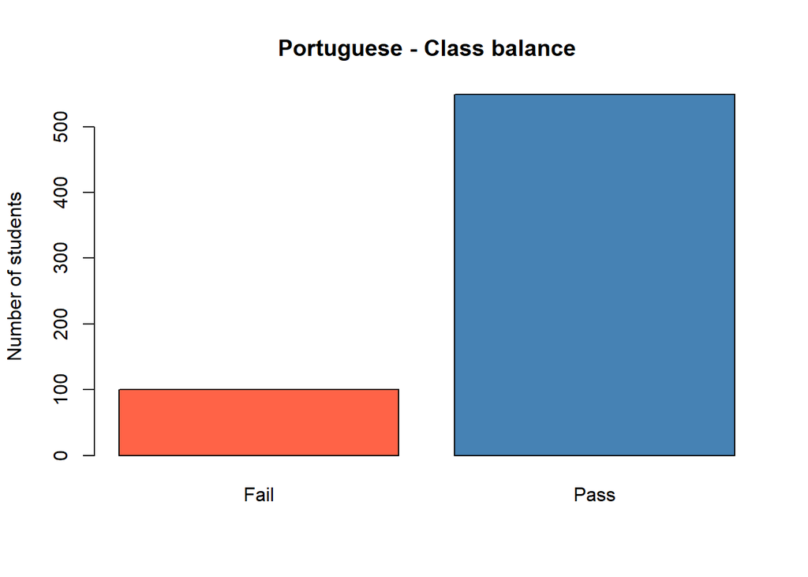

```r
par(mfrow = c(1, 1))
barplot(table(d2$pass),
        names.arg = c("Fail", "Pass"),
        col  = c("tomato", "steelblue"),
        main = "Portuguese - Class balance",
        ylab = "Number of students")
```

##### 3b. Boxplots

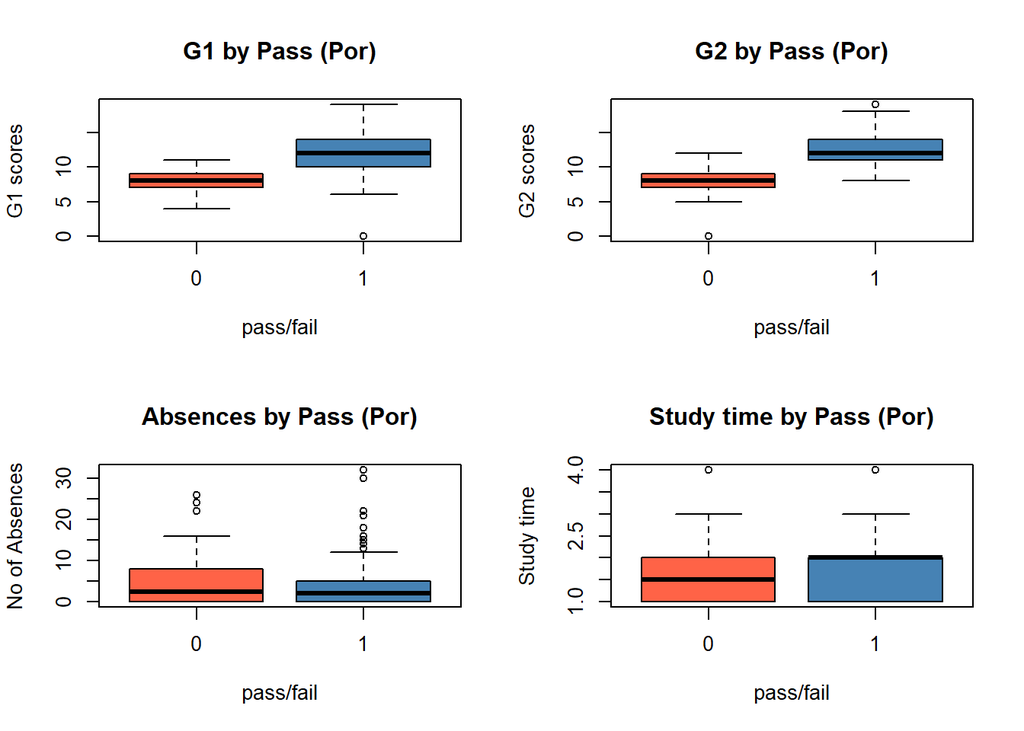

```r
par(mfrow = c(2, 2))
boxplot(G1 ~ pass, data = d2,
        xlab = "pass/fail", ylab = "G1 scores",
        main = "G1 by Pass (Por)",
        col = c("tomato", "steelblue"))

boxplot(G2 ~ pass, data = d2,
        xlab = "pass/fail", ylab = "G2 scores",
        main = "G2 by Pass (Por)",
        col = c("tomato", "steelblue"))

boxplot(absences ~ pass, data = d2,
        xlab = "pass/fail", ylab = "No of Absences",
        main = "Absences by Pass (Por)",
        col = c("tomato", "steelblue"))

boxplot(studytime ~ pass, data = d2,
        xlab = "pass/fail", ylab = "Study time",
        main = "Study time by Pass (Por)",
        col = c("tomato", "steelblue"))
```

##### 3c. Categorical features vs pass rate

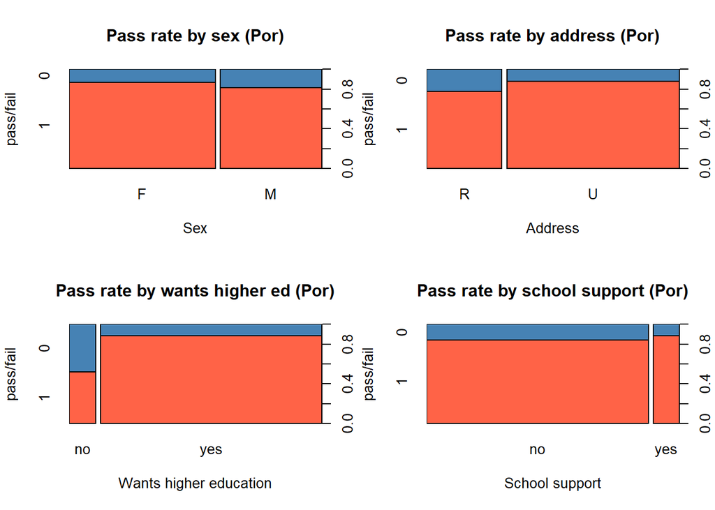

```r
par(mfrow = c(2, 2))
spineplot(as.factor(d2$pass) ~ as.factor(d2$sex),
          xlab = "Sex", ylab = "pass/fail",
          main = "Pass rate by sex (Por)",
          col = c("tomato", "steelblue"))
spineplot(as.factor(d2$pass) ~ as.factor(d2$address),
          xlab = "Address", ylab = "pass/fail",
          main = "Pass rate by address (Por)",
          col = c("tomato", "steelblue"))
spineplot(as.factor(d2$pass) ~ as.factor(d2$higher),
          xlab = "Wants higher education", ylab = "pass/fail",
          main = "Pass rate by wants higher ed (Por)",
          col = c("tomato", "steelblue"))
spineplot(as.factor(d2$pass) ~ as.factor(d2$schoolsup),
          main = "Pass rate by school support (Por)",
          xlab = "School support", ylab = "pass/fail",
          col = c("tomato", "steelblue"))
```

##### 3d. Past failures vs pass

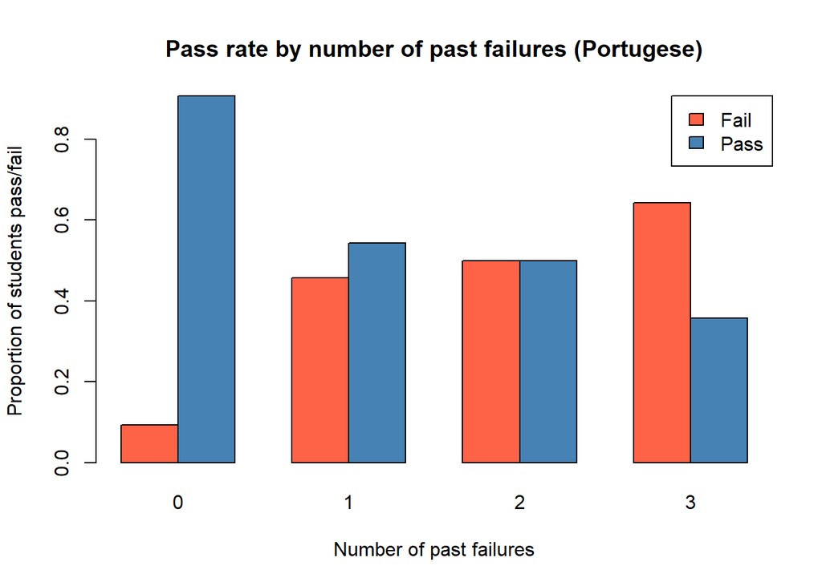

```r
# Past failures vs pass rate
par(mfrow = c(1, 1))

# Build a table: rows = no of failures (0,1,2,3), columns = fail/pass
tab <- table(d2$failures, d2$pass)
colnames(tab) <- c("Fail", "Pass")

# Convert to proportions WITHIN each failure level
# (each row sums to 1, so we see "of students with X failures, what % passed")
prop_tab <- prop.table(tab, margin = 1)

barplot(t(prop_tab),
        beside = TRUE,
        col = c("tomato", "steelblue"),
        legend.text = c("Fail", "Pass"),
        args.legend = list(x = "topright"),
        main = "Pass rate by number of past failures (Portugese)",
        xlab = "Number of past failures",
        ylab = "Proportion of students pass/fail")
```

##### 3e. Correlation heatmap

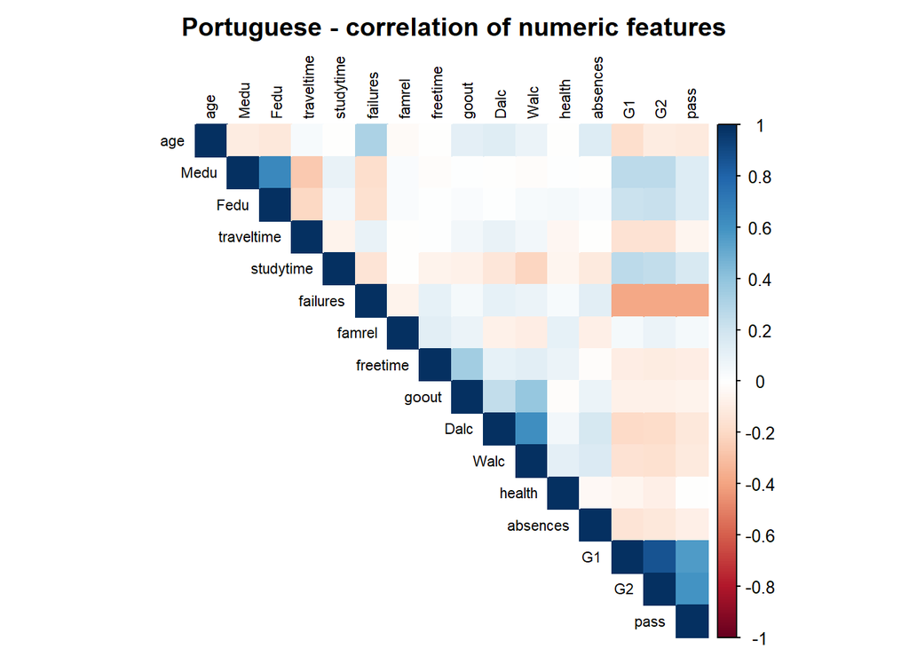

```r
num_cols <- sapply(d2, is.numeric)
cor_mat  <- cor(d2[, num_cols])
corrplot(cor_mat, method = "color", type = "upper",
         tl.cex = 0.7, tl.col = "black",
         title = "Portuguese - correlation of numeric features",
         mar = c(0, 0, 2, 0))
```

#### 4. Train / Test split

```r
d2$pass <- as.factor(d2$pass)

n <- nrow(d2)
set.seed(234)
s.in <- sample(1:n, size = 0.8 * n)

d2.tr <- d2[s.in, ]
d2.ts <- d2[-s.in, ]

x.tr <- model.matrix(pass ~ ., data = d2.tr)[ , -1]
x.ts <- model.matrix(pass ~ ., data = d2.ts)[ , -1]
y.tr <- d2.tr$pass

dim(x.tr)
```

```
## [1] 519  41
```

#### 5. Fit LASSO logistic regression

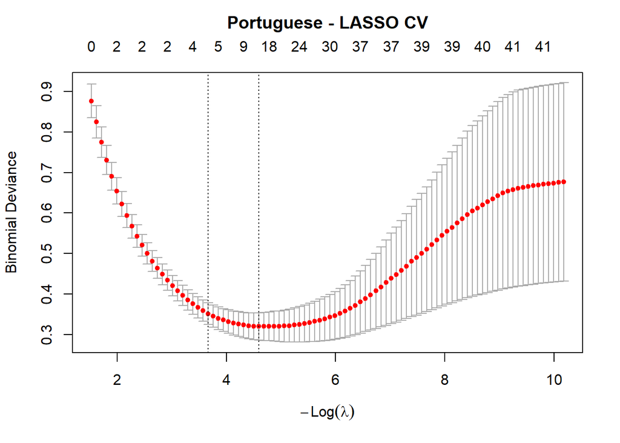

```r
set.seed(234)
cv.l <- cv.glmnet(x = x.tr, y = y.tr,
                  alpha = 1,
                  family = "binomial",
                  nfolds = 10,
                  type.measure = "deviance")

plot(cv.l)
title("Portuguese - LASSO CV", line = 2.5)
```

```r
blam.2 <- cv.l$lambda.min
blam.2
```

```
## [1] 0.01008662
```

```r
mod.l2 <- glmnet(x = x.tr, y = y.tr,
                 alpha = 1,
                 lambda = blam.2,
                 family = "binomial")

coef(mod.l2)
```

```
## 42 x 1 sparse Matrix of class "dgCMatrix"
##                            s0
## (Intercept)      -15.30424495
## schoolMS          -0.02274032
## sexM               .
## age                0.13657303
## addressU           .
## famsizeLE3         .
## PstatusT           .
## Medu               .
## Fedu               .
## Mjobhealth         .
## Mjobother          0.13477065
## Mjobservices       .
## Mjobteacher        .
## Fjobhealth         .
## Fjobother          .
## Fjobservices       .
## Fjobteacher        .
## reasonhome         .
## reasonother        .
## reasonreputation   0.01588832
## guardianmother     .
## guardianother      .
## traveltime         .
## studytime          .
## failures          -0.14015265
## schoolsupyes       .
## famsupyes          .
## paidyes           -0.36551494
## activitiesyes      .
## nurseryyes         .
## higheryes          0.35568040
## internetyes        .
## romanticyes        .
## famrel            -0.08301022
## freetime           .
## goout             -0.02981977
## Dalc              -0.05831891
## Walc              -0.08066781
## health             .
## absences           .
## G1                 0.40995163
## G2                 1.14522717
```

```r
sum(coef(mod.l2) != 0) - 1
```

```
## [1] 13
```

#### 6. Predict on the test set

```r
prob.2 <- predict(mod.l2, newx = x.ts, type = "response")
pred.2 <- ifelse(prob.2 > 0.5, 1, 0)
```

#### 7. Model Evaluation

```r
# Confusion matrix
cm.por <- table(Predicted = pred.2, Actual = d2.ts$pass)
cm.por
```

```
##          Actual
## Predicted   0   1
##         0  12   6
##         1   5 107
```

```r
# Accuracy, sensitivity, specificity
TN.p <- cm.por["0","0"]; FP.p <- cm.por["1","0"]
FN.p <- cm.por["0","1"]; TP.p <- cm.por["1","1"]

acc.por  <- (TP.p + TN.p) / (TP.p + TN.p + FP.p + FN.p)
sens.por <- TP.p / (TP.p + FN.p)
spec.por <- TN.p / (TN.p + FP.p)

acc.por
```

```
## [1] 0.9153846
```

```r
sens.por
```

```
## [1] 0.9469027
```

```r
spec.por
```

```
## [1] 0.7058824
```

##### ROC curve and AUC

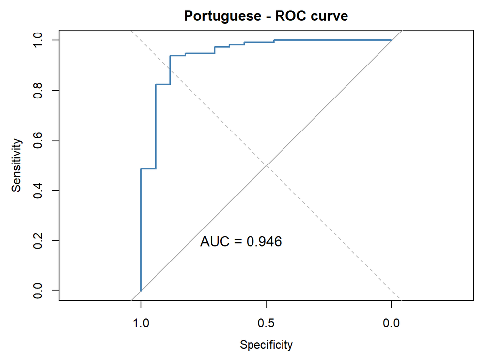

```r
roc.2 <- roc(response  = as.numeric(as.character(d2.ts$pass)),
             predictor = as.numeric(prob.2),
             quiet = TRUE)

plot(roc.2, col = "steelblue", lwd = 2,
     main = "Portuguese - ROC curve")
abline(a = 0, b = 1, lty = 2, col = "grey")
text(0.6, 0.2, paste("AUC =", round(auc(roc.2), 3)), cex = 1.2)
```

```r
auc.por <- as.numeric(auc(roc.2))
auc.por
```

```
## [1] 0.9458615
```

### FINAL COMPARISON

```r
summary_tab <- data.frame(
  Subject     = c("Math", "Portuguese"),
  Best_Lambda = c(blam.1,   blam.2),
  Accuracy    = round(c(acc.mat,  acc.por),2),
  Sensitivity = round(c(sens.mat, sens.por),2),
  Specificity = round(c(spec.mat, spec.por),2),
  AUC         = round(c(auc.mat,  auc.por),2)
)
print(summary_tab, row.names = FALSE)
```

```
##     Subject Best_Lambda Accuracy Sensitivity Specificity  AUC
##        Math 0.003622192     0.96        0.96        0.95 0.98
##  Portuguese 0.010086624     0.92        0.95        0.71 0.95
```

### WHY LASSO (over plain logistic / Ridge / Best-Subset)?

- The dataset has ~30 features and many one-hot expansions. Best-subset would search 2^30+ models - not practical.
- Plain logistic regression over fits when features are correlated (e.g. G1 and G2 carry overlapping information).
- Ridge shrinks but never zeroes features therefore, harder to interpret.
- LASSO shrinks and selects: it tells us which features matter.